# NSC-R Workshop

Literate programming with RMarkdown

Asier Moneva

06 Jul 2021

# 1 The Basics

## 1.1 Markdown syntax

> Help > RMarkdown Quick Reference

```
How can I format my text?
```

1. This is an
2. ordered list
- This is an unordered list.
  - And this is its sublist.
- For emphasis:
  - *This* is italic and *this* too.
  - **This** is bold and **this** too.
- Special formats:
  - <sup>This</sup> is superscript.
  - <sub>This</sub> is subscript.
  - This is strikethrough.
  - `This` is inline code.
- [This](http://nscr.nl) is hyperlinked text.
- And this.[^1]

You can also add math expressions, such as:

$$y = X\beta + \epsilon$$

Want to run a spell-check in the document? Press `F7`.

## 1.2 Compile your document

Most used output formats:

- `html_document`
- `pdf_document`
- `word_document`

How to customize the output format? See, for example, `?html_document`. For Word, you can use a template document. I named mine `word_template_v0_1.docx`. You can then specify you are using a template in the YAML with the parameter `reference_docx`. Check out [this](https://rmarkdown.rstudio.com/articles_docx.html) blog post by Layton (2015) for a step-by-step tutorial.

Advanced formats with the `bookdown` package (Xie 2017):

- `html_document2`
- `pdf_document2`
- `word_document2`

Why? Cross-referencing.

## 1.3 Chunks and their parts

Use this first chunk to configure your global options and chunk options. Then keep a *lineal*, *organized* workflow. Remember to name your chunks for organization and quick access!

```r
# Global options
options(scipen = 999)

# Chunk options: eval, echo, results, collapse, warning, message, error, include, cache, fig.width, fig.height, fig.dim, out.width, out.height, fig.align, dev, fig.cap, child
knitr::opts_chunk$set(echo = TRUE)
```

Here you can *load* your `packages`. To import crime data, I will use the `crimedata` R package by Ashby (2018) that connects to the Crime Open Database.

```r
# Check if you have already installed this package. If not, install it
if (!requireNamespace("crimedata"))
  install.packages("crimedata")
# Then load it
library(crimedata)

if (!requireNamespace("here"))
  install.packages("here")
library(here)

if (!requireNamespace("kableExtra"))
  install.packages("kableExtra")
library(kableExtra)

if (!requireNamespace("knitr"))
  install.packages("knitr")
library(knitr)

if (!requireNamespace("tidyverse"))
  install.packages("tidyverse")
library(tidyverse)
```

And here you can *import* your data.

```r
crime_data <- get_crime_data()
```

Then, you can *transform* your data to, for example, identify the top three property crime groups in Austin in 2019.

```r
crime_table <- crime_data %>%
  filter(city_name == "Austin" & offense_against == "property") %>%
  group_by(offense_group) %>%
  summarise(count = n()) %>%
  ungroup() %>%
  arrange(desc(count)) %>%
  slice_head(n = 3)
```

In addition, you can display this information in a nice table using the `kableExtra` package. Table 1.1 shows that larceny/theft offenses is the most frequent offense group against property, with 304 records.

Table 1.1: Top three property crime groups in Austin in 2019

| Offense group | Count |
| --- | --- |
| larceny/theft offenses | 304 |
| destruction/damage/vandalism of property (except arson) | 62 |
| fraud offenses (except counterfeiting/forgery and bad checks) | 56 |

Now you may want to *visualize* the data to provide additional context and facilitate interpretation. Figure 1.1 ranks property offense groups by number of registries.

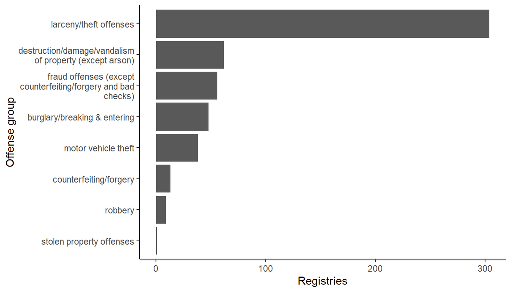

Figure 1.1: Property crime registries by offense group

```r
crime_figure <- crime_data %>%
  filter(city_name == "Austin" & offense_against == "property") %>%
  group_by(offense_group) %>%
  summarise(count = n()) %>%
  ungroup() %>%
  arrange(desc(count)) %>%
  ggplot(mapping = aes(
    x = reorder(
      x = offense_group,
      X = count
    ),
    y = count
  )) +
  geom_col() +
  scale_x_discrete(labels = function(x) str_wrap(
    string = x,
    width = 30
  )) +
  coord_flip() +
  labs(
    x = "Offense group",
    y = "Registries"
  ) +
  theme_classic()
print(crime_figure)
```

And now imagine you want to insert a picture in your report. Let’s include the NSCR logo as Figure 1.2.

To indicate the `path` on which the picture is stored, we used the `here` package by Müller (2020). To learn more, check out [this](https://malco.io/2018/11/05/why-should-i-use-the-here-package-when-i-m-already-using-projects/) blog post on *Why should I use the here package when I’m already using projects?*

[figure not shown]

Figure 1.2: Netherlands Institute for the Study of Crime and Law Enforcement logo

```r
include_graphics(path = here("scripts", "nscr_logo.jpg"))
```

## 1.4 References with Zotero

[This](https://blog.rstudio.com/2020/11/09/rstudio-1-4-preview-citations/) blog post by Joseph J. Allaire (2020), creator of RStudio, details how to integrate citations from Zotero using RMarkdown.

In addition to citing papers, you can also cite R packages like `rmarkdown` (Allaire, Xie, McPherson, et al. 2021)! To retrieve the citation information for a specific package, you can call `citation()` and specify the name of the R package using the `package` parameter.

```r
citation(package = "rmarkdown")
```

```
##
##
##   JJ Allaire and Yihui Xie and Jonathan McPherson and Javier Luraschi
##   and Kevin Ushey and Aron Atkins and Hadley Wickham and Joe Cheng and
##   Winston Chang and Richard Iannone (2021). rmarkdown: Dynamic
##   Documents for R. R package version 2.9. URL
##   https://rmarkdown.rstudio.com.
##
##   Yihui Xie and J.J. Allaire and Garrett Grolemund (2018). R Markdown:
##   The Definitive Guide. Chapman and Hall/CRC. ISBN 9781138359338. URL
##   https://bookdown.org/yihui/rmarkdown.
##
##   Yihui Xie and Christophe Dervieux and Emily Riederer (2020). R
##   Markdown Cookbook. Chapman and Hall/CRC. ISBN 9780367563837. URL
##   https://bookdown.org/yihui/rmarkdown-cookbook.
##
## To see these entries in BibTeX format, use 'print(<citation>,
## bibtex=TRUE)', 'toBibtex(.)', or set
## 'options(citation.bibtex.max=999)'.
```

You can also format your references:

- Regular citation: (Allaire, Xie, McPherson, et al. 2021);
- In-text citation: Allaire, Xie, McPherson, et al. (2021) or just (2021);
- Citation with prefixes or suffixes: (i.e., Allaire, Xie, McPherson, et al. 2021, 10)

The reference list will automatically be compiled at the end of your document. But you can relocate it for your convenience using the following syntax.

```
:::{#refs}
:::
```

# 2 Templates

> New file > R Markdown > From Template

Learn more about the `rticles` package by Allaire, Xie, Wickham, et al. (2021) [here](https://github.com/rstudio/rticles)!

# 3 References

Allaire, Joseph J. 2020. “RStudio 1.4 Preview: Citations.” https://blog.rstudio.com/2020/11/09/rstudio-1-4-preview-citations/.

Allaire, Joseph J., Yihui Xie, Jonathan McPherson, Javier Luraschi, Kevin Ushey, Aron Atkins, Hadley Wickham, Joe Cheng, Winston Chang, and Richard Iannone. 2021. *Rmarkdown: Dynamic Documents for r*. https://rmarkdown.rstudio.com.

Allaire, Joseph J., Yihui Xie, Hadley Wickham, Ramnath Vaidyanathan, Carl Boettiger, Karl Broman, Kirill Müller, et al. 2021. *Rticles: Article Formats for r Markdown*. https://CRAN.R-project.org/package=rticles.

Ashby, Matthew P. J. 2018. “Studying Crime and Place with the Crime Open Database.” https://doi.org/10.31235/osf.io/9y7qz.

Layton, Richard. 2015. “Happy Collaboration with Rmd to Docx.” https://rmarkdown.rstudio.com/articles_docx.html.

Müller, Kirill. 2020. *Here: A Simpler Way to Find Your Files*. https://CRAN.R-project.org/package=here.

Xie, Yihui. 2017. *Bookdown: Authoring Books and Technical Publications with r Markdown*. Boca Raton, FL: CRC Press.

You can wrap up your script with `sessionInfo()`. This function retrieves information about your OS and helps you to keep track the software versions you used, which is useful to write *reproducible examples*.

[session information not shown]

[^1]: is a footnote